# Project 1

Aaron Zelmanov, Muhammad Hafizudeen Mohamad Saman, Nakul Chadha, Kendall Cohen, Michael Geraci, Michael Zhang

2/12/2021

### Basic Exploration

**Average number of people that stay at each hotel**

```r
hotel$num_people <- hotel$adults + hotel$children + hotel$babies
tableHotelInfo <- aggregate(num_people~hotel, data = hotel, mean)
tableHotelInfo$total <- c(sum(hotel$hotel == "City Hotel"), sum(hotel$hotel == "Resort Hotel"))
tableHotelInfo
```

```
##          hotel num_people total
## 1   City Hotel   1.947268 79330
## 2 Resort Hotel   2.009735 40060
```

**Hotel cancellations**

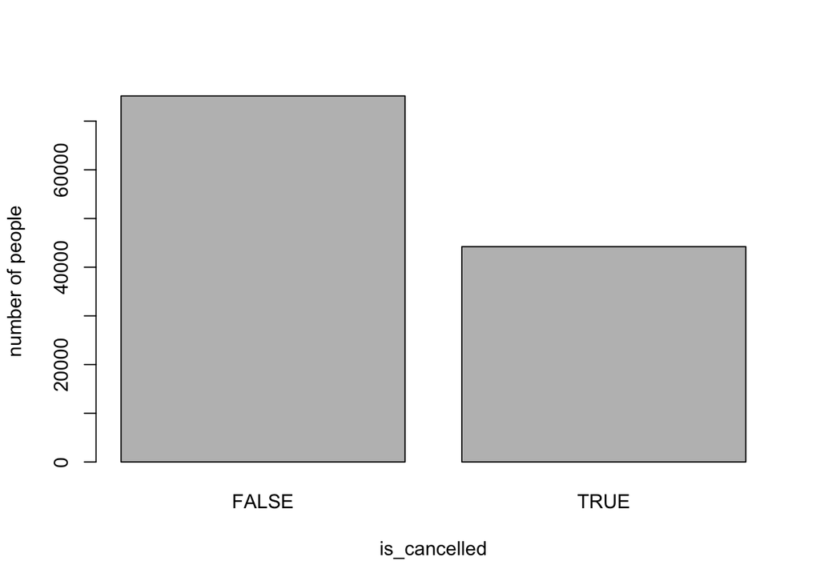

```r
plot(as.factor(hotel$is_canceled), xlab= "is_cancelled", ylab = "number of people")
```

```r
nrow(hotel[hotel$is_canceled == 1,])/nrow(hotel)
```

```
## [1] 0.3704163
```

```r
table_cancellations <- table(hotel$is_canceled, hotel$hotel)
prop.table(table_cancellations)
```

```
##
##         City Hotel Resort Hotel
##   FALSE 0.38720161   0.24238211
##   TRUE  0.27725940   0.09315688
```

```r
addmargins(prop.table(table_cancellations))
```

```
##
##         City Hotel Resort Hotel        Sum
##   FALSE 0.38720161   0.24238211 0.62958372
##   TRUE  0.27725940   0.09315688 0.37041628
##   Sum   0.66446101   0.33553899 1.00000000
```

*Table above shows the number of hotels cancelled and not cancelled. We can see that more than a third canceled their bookings. Total bookings = 119,390*

**Average lead time per hotel**

```r
avg_lead_time_table <- tapply(hotel$lead_time, hotel$hotel, mean, na.rm = TRUE)
avg_lead_time_table
```

```
##   City Hotel Resort Hotel
##    109.73572     92.67569
```

*The table above shows the average lead time per hotel. We can see that people, on average, reserve the City Hotel almost 20 days prior to the Resort Hotel.*

**Number of people by market segment**

```r
#summary(hotel$market_segment)
#plot(hotel$market_segment)
market_seg_table <- table(hotel$market_segment, hotel$hotel)
addmargins(market_seg_table)
```

```
##
##                 City Hotel Resort Hotel    Sum
##   Aviation             237            0    237
##   Complementary        542          201    743
##   Corporate           2986         2309   5295
##   Direct              6093         6513  12606
##   Groups             13975         5836  19811
##   Offline TA/TO      16747         7472  24219
##   Online TA          38748        17729  56477
##   Undefined              2            0      2
##   Sum                79330        40060 119390
```

*The table above shows the number of people per hotel by market segment.*

**What times of the year are busiest?**

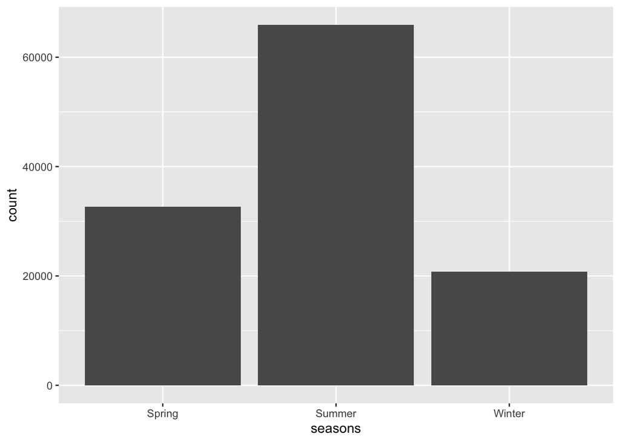

```r
hotel$seasons <- ifelse(hotel$arrival_date_month == "December" | hotel$arrival_date_month == "January" | hotel$arrival_date_month =="February", "Winter", ifelse(hotel$arrival_date_month == "March" | hotel$arrival_date_month == "April" | hotel$arrival_date_month ==  "May",  "Spring", "Summer"))

library("ggplot2")
ggplot(hotel, aes(seasons)) + geom_bar()
```

*Chart above shows how reservations vary with seasons*

**How about the arrival month? Are there any famous months for hotel reservation?**

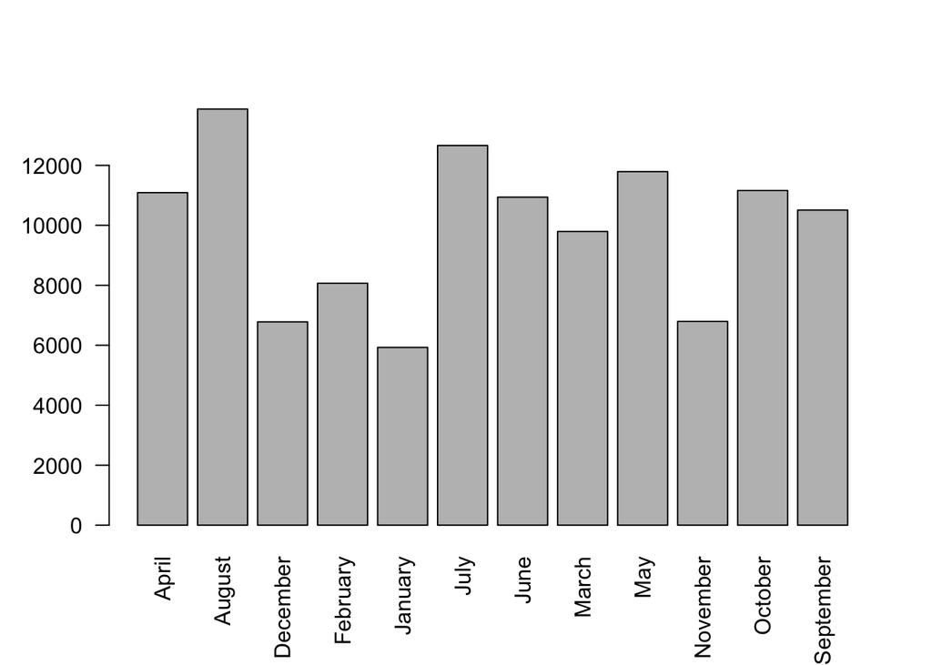

```r
plot(hotel$arrival_date_month, las = 2)
```

```r
table(hotel$arrival_date_month)
```

```
##
##     April    August  December  February   January      July      June     March
##     11089     13877      6780      8068      5929     12661     10939      9794
##       May  November   October September
##     11791      6794     11160     10508
```

*The most famous moth for hotel arrival date is August. In the trend, we can see that the months with the lowest number of arrival months are months at the end and the beginning of the year, particularly from November-February*

### Cancellation Analysis

**Cancellations by month**

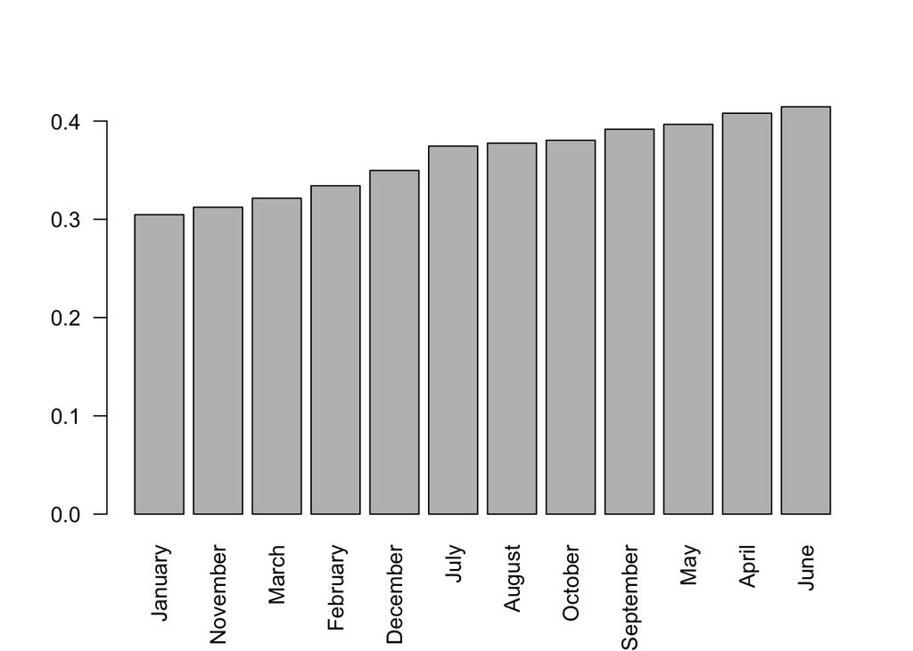

```r
cancellationsbymonth <- tapply(hotel$is_canceled, hotel$arrival_date_month, mean, na.rm = TRUE)
barplot(sort(cancellationsbymonth), las = 2)
```

```
## # A tibble: 10 x 2
##    arrival_date_month num_cancel
##    <fct>                   <int>
##  1 August                   5239
##  2 July                     4742
##  3 May                      4677
##  4 June                     4535
##  5 April                    4524
##  6 October                  4246
##  7 September                4116
##  8 March                    3149
##  9 February                 2696
## 10 December                 2371
```

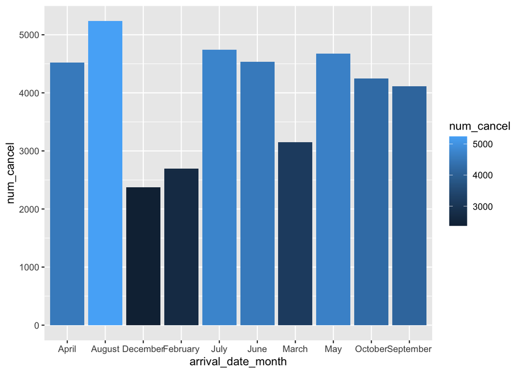

```r
hotel %>% group_by(arrival_date_month) %>% summarise(num_cancel = sum(is_canceled)) %>% arrange(desc(num_cancel)) %>% head(10) %>% print %>% ggplot(aes(x = arrival_date_month, y = num_cancel, fill= num_cancel))+ geom_col()
```

*Most of the months have about 30-40% rate of cancellation, so we cannot definitely say for sure that month affect the rate of cancellation*

**Cancellations by hotel type**

```r
tableCancellationsbyType <- aggregate(is_canceled ~ hotel, data = hotel, sum)
cityHotels <- sum(hotel$hotel == "City Hotel", na.rm = TRUE)
resortHotels <- sum(hotel$hotel == "Resort Hotel", na.rm = TRUE)
tableCancellationsbyType$prop_cancelled <- c(round(33102/cityHotels, 2), round(11122/resortHotels, 2))
tableCancellationsbyType
```

```
##          hotel is_canceled prop_cancelled
## 1   City Hotel       33102           0.42
## 2 Resort Hotel       11122           0.28
```

*Table above shows the number of cancellations per hotel type and the proportion of each hotel’s bookings that are cancelled*

```r
tableCancellationsbyMarket <- aggregate(is_canceled ~ market_segment, data = hotel, length)
tableCancellationsbyMarket
```

```
##   market_segment is_canceled
## 1       Aviation         237
## 2  Complementary         743
## 3      Corporate        5295
## 4         Direct       12606
## 5         Groups       19811
## 6  Offline TA/TO       24219
## 7      Online TA       56477
## 8      Undefined           2
```

**Cancellation by country**

```
## # A tibble: 10 x 2
##    country num_cancel
##    <fct>        <int>
##  1 PRT          27519
##  2 GBR           2453
##  3 ESP           2177
##  4 FRA           1934
##  5 ITA           1333
##  6 DEU           1218
##  7 IRL            832
##  8 BRA            830
##  9 USA            501
## 10 BEL            474
```

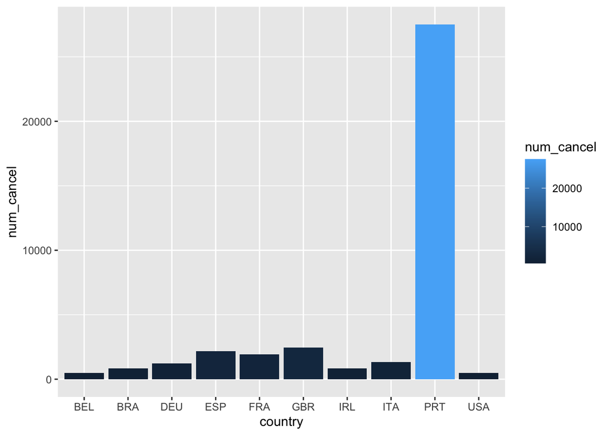

```r
hotel %>% group_by(country) %>% summarise(num_cancel = sum(is_canceled)) %>% arrange(desc(num_cancel)) %>% head(10) %>% print %>% ggplot(aes(x = country, y = num_cancel, fill= num_cancel))+ geom_col()
```

```r
library("GGally")
```

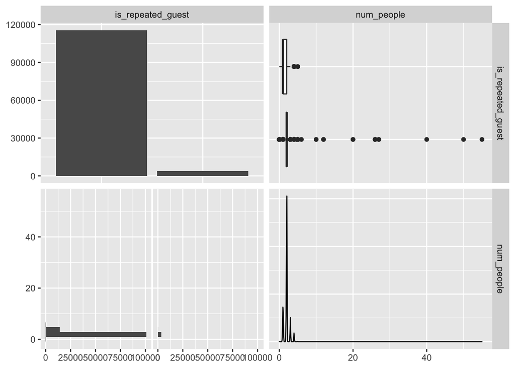

```r
ggpairs(data = hotel, columns = c("is_repeated_guest", "num_people"))
```